# Fitness Activity Analysis - Machine Learning (Coursera)

Rumy

November 19, 2015

### Summary

The steps followed for project was data aquisition, data exploration, data cleansing and finally building and testing the predictive model. The results of the analysis confirm that the model provided by this algorithm achieves a high prediction accuracy (as indicated by several prediction quality indicators).

### Data aquisition

Training data set can be found on the following URL: https://d396qusza40orc.cloudfront.net/predmachlearn/pml-training.csv

Testing data set can be found on the following URL: https://d396qusza40orc.cloudfront.net/predmachlearn/pml-testing.csv

```r
# set seed for reproducibility
set.seed(12121)

# get url for training and test data
trainurl <- "https://d396qusza40orc.cloudfront.net/predmachlearn/pml-training.csv"
testurl <- "https://d396qusza40orc.cloudfront.net/predmachlearn/pml-testing.csv"

# build function to download files and store in sub dir Data, if they do not exist already
getdata <- function(datadir = "./Data") {
       if (!file.exists(datadir)) {
     dir.create(datadir)
     trainUrl <- "http://d396qusza40orc.cloudfront.net/predmachlearn/pml-training.csv"
     testUrl <- "http://d396qusza40orc.cloudfront.net/predmachlearn/pml-testing.csv"
     trainPath <- paste(datadir, "pml-training.csv", sep = "/")
     testPath <- paste(datadir, "pml-test.csv", sep = "/")
     download.file(trainUrl, destfile = trainPath)
     download.file(testUrl, destfile = testPath)
           }
}
getdata()

# load training file
trainraw <- read.csv("./Data/pml-training.csv", header = TRUE, na.strings=c("NA", "#DIV/0!",""))
testraw <- read.csv("./Data/pml-test.csv", header = TRUE, na.strings=c("NA", "#DIV/0!",""))

# Load relevant packages for the project
library(caret)
library(ggplot2)
library(reshape)
library(randomForest)
library(gbm)
# Split training data into train and test (60:40 split)
inTrain <- createDataPartition(y=trainraw$classe, p=0.6, list=FALSE)

sampletrain <- trainraw[inTrain, ]
sampletest <- trainraw[-inTrain, ]
```

Some aspects of the data upon visual inspection are: - file is comma separated - quite a few missing(NA) and error (Div/0) values - some rows e.g. record ID, user_name and timestamp columns can be eliminated to overfit the model to non relevant variables.

### Data Cleansing

```r
# first identify and remove columns with zero variation from training data
zeroV <- nearZeroVar(sampletrain, saveMetrics = TRUE)
zerovnames <- rownames(zeroV[zeroV$zeroVar==TRUE, ])
zerovnames <- names(sampletrain) %in% zerovnames
sampletrain <- sampletrain[!zerovnames]

# remove columns with > 65% of data missing or with errors

traininterim <- sampletrain
for(i in 1:length(sampletrain)) {
    if( sum( is.na( sampletrain[, i] ) ) /nrow(sampletrain) >= .65 ) {
        for(k in 1:length(traininterim)) {
            if( length( grep(names(sampletrain[i]), names(traininterim)[k]) ) ==1)  {
                #remove col with significant NA's
                traininterim <- traininterim[ , -k] #Remove that column
            }
        }
    }
}

sampletrain <- traininterim
rm(traininterim, zeroV, zerovnames)

# remove columns 1 thru 7 which include row id, user name and time stamp data which should not be mixed up with reads from body sensors to predict correctness of exercise form

sampletrain <- sampletrain[, c(-1:-7)]

# eliminate data cleansing on test and testraw datasets
colt <- colnames(sampletrain)
coltr <- colnames(sampletrain[, !names(sampletrain) %in% c("classe")])
sampletest <- sampletest[colt]
testraw <- testraw[coltr]
```

### Exploratory Analysis

Correlation plot shown here tells us that quite a few variables are correlated

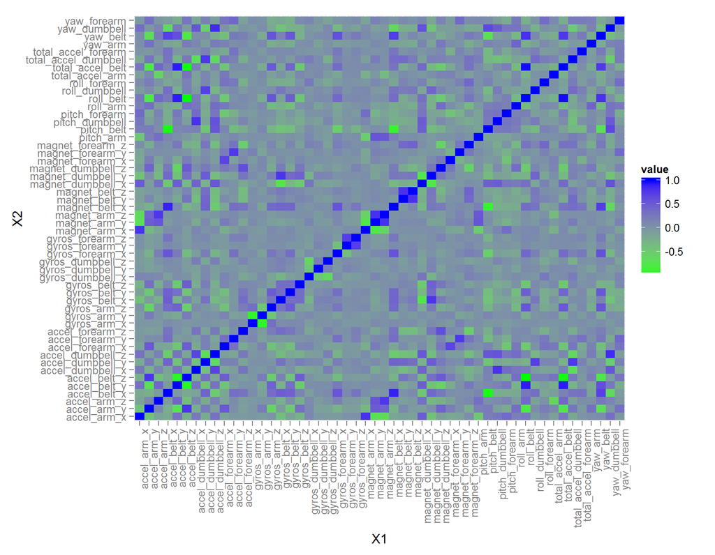

### Train the Model using RandomForest

```r
# First will use all the variables without running PCA

time1 = proc.time()
(rfFit1 = train(sampletrain$classe ~ ., method = "rf", data=sampletrain, trControl = trainControl(method="repeatedcv", repeats=1, number=5, classProbs=TRUE), prox=TRUE, importance=TRUE))
```

```
## Random Forest
##
## 11776 samples
##    52 predictor
##     5 classes: 'A', 'B', 'C', 'D', 'E'
##
## No pre-processing
## Resampling: Cross-Validated (5 fold, repeated 1 times)
## Summary of sample sizes: 9421, 9421, 9420, 9421, 9421
## Resampling results across tuning parameters:
##
##   mtry  Accuracy   Kappa      Accuracy SD  Kappa SD
##    2    0.9881962  0.9850669  0.003349438  0.004238883
##   27    0.9898097  0.9871090  0.001645313  0.002081508
##   52    0.9847145  0.9806634  0.002736374  0.003462208
##
## Accuracy was used to select the optimal model using  the largest value.
## The final value used for the model was mtry = 27.
```

```r
time2 = proc.time()
(time_taken = time2 - time1)
```

```
##    user  system elapsed
## 2290.75   15.24 2309.43
```

```r
print(rfFit1$finalModel)
```

```
##
## Call:
##  randomForest(x = x, y = y, mtry = param$mtry, importance = TRUE,      proximity = TRUE)
##                Type of random forest: classification
##                      Number of trees: 500
## No. of variables tried at each split: 27
##
##         OOB estimate of  error rate: 0.87%
## Confusion matrix:
##      A    B    C    D    E class.error
## A 3342    3    2    0    1 0.001792115
## B   23 2248    8    0    0 0.013602457
## C    0   15 2029   10    0 0.012171373
## D    0    1   28 1900    1 0.015544041
## E    0    1    5    4 2155 0.004618938
```

Now I will try principal component analysis to reduce the number of dimensions, maintain orthogonality and improve performance without sacrificing accuracy

```r
preProc <- preProcess(sampletrain[,  !names(sampletrain) %in% c("classe")], method="pca", thresh=0.90)
preProc
```

```
## Created from 11776 samples and 52 variables
##
## Pre-processing:
##   - centered (52)
##   - ignored (0)
##   - principal component signal extraction (52)
##   - scaled (52)
##
## PCA needed 20 components to capture 90 percent of the variance
```

```r
trainPCA <- predict(preProc, sampletrain[,!names(sampletrain) %in% c("classe")])

time1 = proc.time()
(rfFit2 <- train(sampletrain$classe ~ ., method = "rf", data=trainPCA, trControl = trainControl(method="repeatedcv", repeats=1, number=5, classProbs=TRUE ), prox=TRUE))
```

```
## Random Forest
##
## 11776 samples
##    19 predictor
##     5 classes: 'A', 'B', 'C', 'D', 'E'
##
## No pre-processing
## Resampling: Cross-Validated (5 fold, repeated 1 times)
## Summary of sample sizes: 9421, 9422, 9420, 9420, 9421
## Resampling results across tuning parameters:
##
##   mtry  Accuracy   Kappa      Accuracy SD  Kappa SD
##    2    0.9606826  0.9502475  0.007059303  0.008920353
##   11    0.9546532  0.9426223  0.005084481  0.006411559
##   20    0.9493879  0.9359717  0.004712717  0.005933016
##
## Accuracy was used to select the optimal model using  the largest value.
## The final value used for the model was mtry = 2.
```

```r
time2 = proc.time()
(time_taken = time2 - time1)
```

```
##    user  system elapsed
## 1574.04   16.17 1594.35
```

```r
print(rfFit2$finalModel)
```

```
##
## Call:
##  randomForest(x = x, y = y, mtry = param$mtry, proximity = TRUE)
##                Type of random forest: classification
##                      Number of trees: 500
## No. of variables tried at each split: 2
##
##         OOB estimate of  error rate: 3.09%
## Confusion matrix:
##      A    B    C    D    E class.error
## A 3321    7    8   10    2 0.008064516
## B   52 2174   46    4    3 0.046072839
## C    6   34 1984   22    8 0.034079844
## D    6    3   90 1825    6 0.054404145
## E    2   24   18   13 2108 0.026327945
```

**Random Forest Model Results and Accuracy**

Performance gain with PCA was at the cost of ~ 3% drop in accuracy. Hence I will go with testing the model without using PCA. Also, variable importance analysis plot that displays more insights about the relative importance of variables in the model.

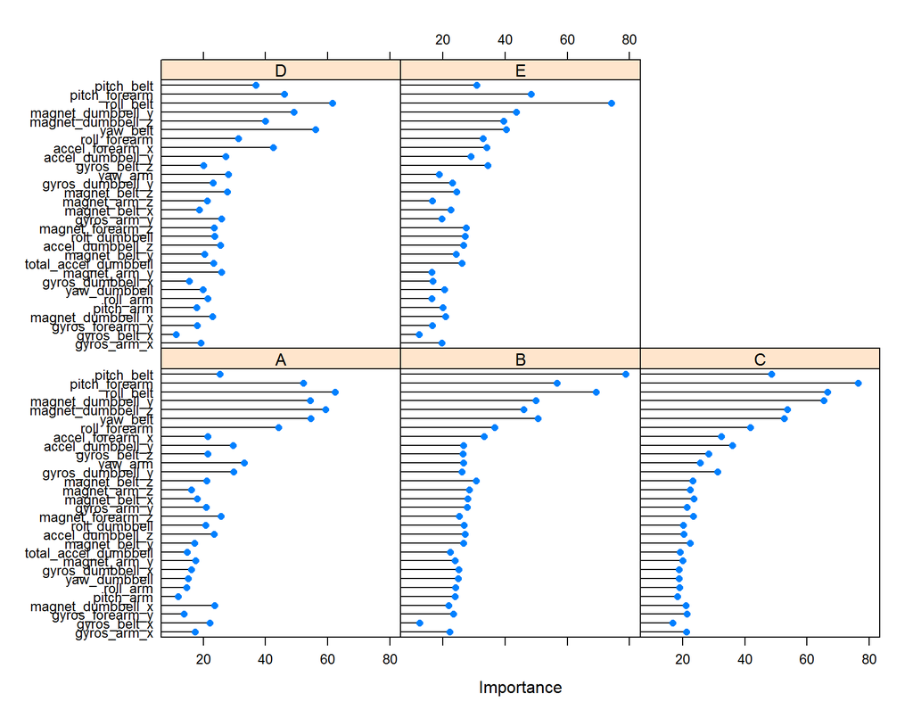

```r
rfImp <- varImp(rfFit1, scale = FALSE)
plot(rfImp, top = 30)
```

**Accuracy with test data from Sample**

```r
confusionMatrix(predict(rfFit1, newdata = sampletest), sampletest$classe)
```

```
## Confusion Matrix and Statistics
##
##           Reference
## Prediction    A    B    C    D    E
##          A 2230   14    0    0    0
##          B    0 1498   10    0    1
##          C    1    6 1353   26    1
##          D    0    0    5 1258    7
##          E    1    0    0    2 1433
##
## Overall Statistics
##
##                Accuracy : 0.9906
##                  95% CI : (0.9882, 0.9926)
##     No Information Rate : 0.2845
##     P-Value [Acc > NIR] : < 2.2e-16
##
##                   Kappa : 0.9881
##  Mcnemar's Test P-Value : NA
##
## Statistics by Class:
##
##                      Class: A Class: B Class: C Class: D Class: E
## Sensitivity            0.9991   0.9868   0.9890   0.9782   0.9938
## Specificity            0.9975   0.9983   0.9948   0.9982   0.9995
## Pos Pred Value         0.9938   0.9927   0.9755   0.9906   0.9979
## Neg Pred Value         0.9996   0.9968   0.9977   0.9957   0.9986
## Prevalence             0.2845   0.1935   0.1744   0.1639   0.1838
## Detection Rate         0.2842   0.1909   0.1724   0.1603   0.1826
## Detection Prevalence   0.2860   0.1923   0.1768   0.1619   0.1830
## Balanced Accuracy      0.9983   0.9925   0.9919   0.9882   0.9966
```

Applying the RandomForest model fit rfFit1 (w/o PCA) to sample test data yeilded pretty good accuracy ~ 99%

### Train the model using Gradient Boosting Machine (gbm)

To check if can get a reasonable accuracy with much better performance, I will train the model using gbm algorithm on PCA components created earlier, using K fold cross validation of 10 folds.

```r
time1 = proc.time()
(gbmFit <- train(sampletrain$classe ~ ., method = "gbm", data=trainPCA, trControl = trainControl(method="repeatedcv", repeats=1, number=10, classProbs=TRUE ), verbose = FALSE))
```

```
## Stochastic Gradient Boosting
##
## 11776 samples
##    19 predictor
##     5 classes: 'A', 'B', 'C', 'D', 'E'
##
## No pre-processing
## Resampling: Cross-Validated (10 fold, repeated 1 times)
## Summary of sample sizes: 10599, 10597, 10599, 10599, 10599, 10597, ...
## Resampling results across tuning parameters:
##
##   interaction.depth  n.trees  Accuracy   Kappa      Accuracy SD
##   1                   50      0.5403347  0.4080608  0.011661812
##   1                  100      0.5986740  0.4874153  0.012120964
##   1                  150      0.6227064  0.5194329  0.011337622
##   2                   50      0.6328959  0.5327873  0.011994456
##   2                  100      0.6979429  0.6167231  0.013510739
##   2                  150      0.7369199  0.6665734  0.010296603
##   3                   50      0.6896214  0.6058502  0.011589515
##   3                  100      0.7618891  0.6981518  0.008783501
##   3                  150      0.7995947  0.7461222  0.008409357
##   Kappa SD
##   0.01432618
##   0.01481018
##   0.01399130
##   0.01491146
##   0.01682252
##   0.01297167
##   0.01449343
##   0.01089434
##   0.01051995
##
## Tuning parameter 'shrinkage' was held constant at a value of 0.1
##
## Tuning parameter 'n.minobsinnode' was held constant at a value of 10
## Accuracy was used to select the optimal model using  the largest value.
## The final values used for the model were n.trees = 150,
##  interaction.depth = 3, shrinkage = 0.1 and n.minobsinnode = 10.
```

```r
time2 = proc.time()
(time_taken = time2 - time1)
```

```
##    user  system elapsed
##  302.38    0.65  307.26
```

**Boosted Regression Model Results and Accuracy**

```
## Confusion Matrix and Statistics
##
##           Reference
## Prediction    A    B    C    D    E
##          A 3075   62   60  129   22
##          B  189 1828  156   54   52
##          C   88  116 1767   59   24
##          D   72   53  211 1560   34
##          E   80  117  116   94 1758
##
## Overall Statistics
##
##                Accuracy : 0.8482
##                  95% CI : (0.8416, 0.8546)
##     No Information Rate : 0.2976
##     P-Value [Acc > NIR] : < 2.2e-16
##
##                   Kappa : 0.8077
##  Mcnemar's Test P-Value : < 2.2e-16
##
## Statistics by Class:
##
##                      Class: A Class: B Class: C Class: D Class: E
## Sensitivity            0.8776   0.8401   0.7649   0.8228   0.9302
## Specificity            0.9670   0.9530   0.9697   0.9626   0.9588
## Pos Pred Value         0.9185   0.8021   0.8603   0.8083   0.8120
## Neg Pred Value         0.9491   0.9634   0.9441   0.9659   0.9863
## Prevalence             0.2976   0.1848   0.1962   0.1610   0.1605
## Detection Rate         0.2611   0.1552   0.1501   0.1325   0.1493
## Detection Prevalence   0.2843   0.1935   0.1744   0.1639   0.1838
## Balanced Accuracy      0.9223   0.8965   0.8673   0.8927   0.9445
```

```r
confusionMatrix(sampletest$classe, predict(gbmFit, predict(preProc, sampletest)))
```

```
## Confusion Matrix and Statistics
##
##           Reference
## Prediction    A    B    C    D    E
##          A 1984   70   47  108   23
##          B  149 1142  125   48   54
##          C   89   96 1111   57   15
##          D   63   36  149  995   43
##          E   68  119   97   81 1077
##
## Overall Statistics
##
##                Accuracy : 0.8041
##                  95% CI : (0.7951, 0.8128)
##     No Information Rate : 0.2999
##     P-Value [Acc > NIR] : < 2.2e-16
##
##                   Kappa : 0.7518
##  Mcnemar's Test P-Value : < 2.2e-16
##
## Statistics by Class:
##
##                      Class: A Class: B Class: C Class: D Class: E
## Sensitivity            0.8432   0.7806   0.7266   0.7719   0.8886
## Specificity            0.9549   0.9411   0.9593   0.9556   0.9450
## Pos Pred Value         0.8889   0.7523   0.8121   0.7737   0.7469
## Neg Pred Value         0.9343   0.9493   0.9355   0.9552   0.9789
## Prevalence             0.2999   0.1865   0.1949   0.1643   0.1545
## Detection Rate         0.2529   0.1456   0.1416   0.1268   0.1373
## Detection Prevalence   0.2845   0.1935   0.1744   0.1639   0.1838
## Balanced Accuracy      0.8990   0.8608   0.8430   0.8638   0.9168
```

Accuracy at 80% on the sample test is pretty close to sample train data which indicates that the model was not overfit. However, to predict the outcome from test file (for the second part of the exercise), I will use the more accurate RF model rfFit1 (without PCA).

**Save training model**

```r
save(rfFit1, file="rfFit1.RData")
```

### Apply the RF fit to test file data and write back to local file for submission

```r
load(file="rfFit1.RData", verbose=TRUE)
```

```
## Loading objects:
##   rfFit1
```

```r
predfinal <- predict(rfFit1, testraw)
pml_write_files <- function(x){
    n = length(x)
    for(i in 1:n){
        filename = paste0("problem_id_",i,".txt")
        write.table(x[i],file=filename,quote=FALSE,row.names=FALSE,col.names=FALSE)
    }
}

pml_write_files(predfinal)
```